# A Big Data Analysis on YouTube Trending Videos in the United States

Mohammad A. Kazemivarnamkhasti, Rami Shehadeh, Wenxuan Wan

### Introduction

It’s hard imaging modern society operating YouTube, the video sharing platform goliath. YouTube is the second most popular website on Earth with 1.8 billion user visits every month, falling short to only Google, its parent website. With the massive amount of traffic YouTube receives, it’s hard for a single video to get any attention. However YouTube superstars like Mr.Beast, T-Series, and PewDiePie seem to effortlessly soar into the trending videos with ease. This begs the question, what makes a video go viral? What kinds of video would have the highest chances of reaching the most people? What kinds of videos would stir up the most activity in your comments? Let’s first take a step back. Why do we even want to succeed on YouTube? Many content creators pour hundreds of hours into a single video just to hope that people watch it and stay engaged. Creative drive aside, having a successful YouTube channel would mean a stream of ad revenue and sponsorships, successful YouTube channels can even appear on national television or other traditional media as guests. However, this is all contingent on your videos doing well. In this analysis we seek to answer the traits do success videos have in common? What are their audience engagements like, and what topics do they cover?

### Data Collection

For this anayslsis we collected our YouTube trending dataset from Kaggle. More specifically this [link](https://www.kaggle.com/datasets/rsrishav/youtube-trending-video-dataset?select=US_youtube_trending_data.csv). This takes you to a dataset containing trending YouTube data from 2020 to 2022. This data is comprised of multiple .csv files. Since we’re mainly interested in the US data, we’ll be using US_youtube_trending_data.csv. Pandas and Numpy are used to do basic data science and data manipulation.

```python
import pandas as pd
import numpy as np
import math
from matplotlib import pyplot as plt
import seaborn as sns
from scipy import stats

import warnings
warnings.simplefilter(action='ignore', category=FutureWarning)
```

## Cleaning the Data

Before any analysis can be done we first must clean the data so that its more workable and presentable.

Lets first see what our data looks like

```python
df = pd.read_csv("US_youtube_trending_data.csv")
df.head()
```

|  | video_id | title | publishedAt | channelId | channelTitle | categoryId | trending_date | tags | view_count | likes | dislikes | comment_count | thumbnail_link | comments_disabled | ratings_disabled | description |
| --- | --- | --- | --- | --- | --- | --- | --- | --- | --- | --- | --- | --- | --- | --- | --- | --- |
| 0 | 3C66w5Z0ixs | I ASKED HER TO BE MY GIRLFRIEND... | 2020-08-11T19:20:14Z | UCvtRTOMP2TqYqu51xNrqAzg | Brawadis | 22 | 2020-08-12T00:00:00Z | brawadis\|prank\|basketball\|skits\|ghost\|funny vi... | 1514614 | 156908 | 5855 | 35313 | https://i.ytimg.com/vi/3C66w5Z0ixs/default.jpg | False | False | SUBSCRIBE to BRAWADIS ▶ http://bit.ly/Subscrib... |
| 1 | M9Pmf9AB4Mo | Apex Legends \| Stories from the Outlands – “Th... | 2020-08-11T17:00:10Z | UC0ZV6M2THA81QT9hrVWJG3A | Apex Legends | 20 | 2020-08-12T00:00:00Z | Apex Legends\|Apex Legends characters\|new Apex ... | 2381688 | 146739 | 2794 | 16549 | https://i.ytimg.com/vi/M9Pmf9AB4Mo/default.jpg | False | False | While running her own modding shop, Ramya Pare... |
| 2 | J78aPJ3VyNs | I left youtube for a month and THIS is what ha... | 2020-08-11T16:34:06Z | UCYzPXprvl5Y-Sf0g4vX-m6g | jacksepticeye | 24 | 2020-08-12T00:00:00Z | jacksepticeye\|funny\|funny meme\|memes\|jacksepti... | 2038853 | 353787 | 2628 | 40221 | https://i.ytimg.com/vi/J78aPJ3VyNs/default.jpg | False | False | I left youtube for a month and this is what ha... |
| 3 | kXLn3HkpjaA | XXL 2020 Freshman Class Revealed - Official An... | 2020-08-11T16:38:55Z | UCbg_UMjlHJg_19SZckaKajg | XXL | 10 | 2020-08-12T00:00:00Z | xxl freshman\|xxl freshmen\|2020 xxl freshman\|20... | 496771 | 23251 | 1856 | 7647 | https://i.ytimg.com/vi/kXLn3HkpjaA/default.jpg | False | False | Subscribe to XXL → http://bit.ly/subscribe-xxl... |
| 4 | VIUo6yapDbc | Ultimate DIY Home Movie Theater for The LaBran... | 2020-08-11T15:10:05Z | UCDVPcEbVLQgLZX0Rt6jo34A | Mr. Kate | 26 | 2020-08-12T00:00:00Z | The LaBrant Family\|DIY\|Interior Design\|Makeove... | 1123889 | 45802 | 964 | 2196 | https://i.ytimg.com/vi/VIUo6yapDbc/default.jpg | False | False | Transforming The LaBrant Family's empty white ... |

We see that there are alot of information present and many are abbreviated to numbers. Lets first translte the categoryId into english tags. This is done by referring to the YouTube video category ID list found here: https://mixedanalytics.com/youtube-video-category-id-list/

```python
cat_id = {
    1 :"Film & Animation",
    2 : "Autos & Vehicles",
    10: "Music",
    15: "Pets & Animals",
    17: "Sports",
    18: "Short Movies",
    19: "Travel & Events",
    20: "Gaming",
    21: "Videoblogging",
    22: "People & Blogs",
    23: "Comedy",
    24: "Entertainment",
    25: "News & Politics",
    26: "Howto & Style",
    27: "Education",
    28: "Science & Technology",
    29: "Nonprofits & Activism",
    30: "Movies",
    31: "Anime/Animation",
    32: "Action/Adventure",
    33: "Classics",
    34: "Comedy",
    35: "Documentary",
    36: "Drama",
    37: "Family",
    38: "Foreign",
    39: "Horror",
    40: "Sci-Fi/Fantasy",
    41: "Thriller",
    42: "Shorts",
    43: "Shows",
    44: "Trailers"
}
```

```python
df_c = df['categoryId'].tolist()
cat_names = [None] * len(df_c)
for i in range(len(df_c)):
    cat_names[i] = cat_id[df_c[i]]
df.drop(columns = ['categoryId'], inplace= True)
df['category'] = cat_names
```

There's still alot of information that are not import to us such as the video id, thumbnail url, or description. Lets remove them and the dataframe.

```python
df.drop(columns = ['video_id', 'channelId', 'description','thumbnail_link'], inplace = True)
df
```

|  | title | publishedAt | channelTitle | trending_date | tags | view_count | likes | dislikes | comment_count | comments_disabled | ratings_disabled | category |
| --- | --- | --- | --- | --- | --- | --- | --- | --- | --- | --- | --- | --- |
| 0 | I ASKED HER TO BE MY GIRLFRIEND... | 2020-08-11T19:20:14Z | Brawadis | 2020-08-12T00:00:00Z | brawadis\|prank\|basketball\|skits\|ghost\|funny vi... | 1514614 | 156908 | 5855 | 35313 | False | False | People & Blogs |
| 1 | Apex Legends \| Stories from the Outlands – “Th... | 2020-08-11T17:00:10Z | Apex Legends | 2020-08-12T00:00:00Z | Apex Legends\|Apex Legends characters\|new Apex ... | 2381688 | 146739 | 2794 | 16549 | False | False | Gaming |
| 2 | I left youtube for a month and THIS is what ha... | 2020-08-11T16:34:06Z | jacksepticeye | 2020-08-12T00:00:00Z | jacksepticeye\|funny\|funny meme\|memes\|jacksepti... | 2038853 | 353787 | 2628 | 40221 | False | False | Entertainment |
| 3 | XXL 2020 Freshman Class Revealed - Official An... | 2020-08-11T16:38:55Z | XXL | 2020-08-12T00:00:00Z | xxl freshman\|xxl freshmen\|2020 xxl freshman\|20... | 496771 | 23251 | 1856 | 7647 | False | False | Music |
| 4 | Ultimate DIY Home Movie Theater for The LaBran... | 2020-08-11T15:10:05Z | Mr. Kate | 2020-08-12T00:00:00Z | The LaBrant Family\|DIY\|Interior Design\|Makeove... | 1123889 | 45802 | 964 | 2196 | False | False | Howto & Style |
| ... | ... | ... | ... | ... | ... | ... | ... | ... | ... | ... | ... | ... |
| 172185 | Minecraft but I have 1,000,000 XP | 2022-12-11T15:00:03Z | Craftee | 2022-12-16T00:00:00Z | minecraft\|minecraft but\|new minecraft\|craftee\|... | 1190457 | 23172 | 0 | 1497 | False | False | Gaming |
| 172186 | Paddy Pimblett Octagon Interview \| UFC 282 | 2022-12-11T05:33:54Z | UFC - Ultimate Fighting Championship | 2022-12-16T00:00:00Z | ufc\|mma\|ultimate fighting championship\|UFC 282... | 1446095 | 11069 | 0 | 7736 | False | False | Sports |
| 172187 | REVEALING Our BABY'S NAME! 😱 | 2022-12-10T17:46:12Z | The Royalty Family | 2022-12-16T00:00:00Z | The Royalty Family\|Royalty Family\|Andrea Espad... | 3103034 | 76518 | 0 | 18022 | False | False | People & Blogs |
| 172188 | Star Wars Jedi: Survivor - Official Reveal Tra... | 2022-12-09T01:52:37Z | EA Star Wars | 2022-12-16T00:00:00Z | star wars\|star wars jedi survivor\|jedi survivo... | 5286961 | 174278 | 0 | 12748 | False | False | Gaming |
| 172189 | Chris Brown - It's Giving Christmas | 2022-12-09T17:00:26Z | ChrisBrownVEVO | 2022-12-16T00:00:00Z | Chris brown its giving Christmas\|chris brown t... | 889375 | 60867 | 0 | 2918 | False | False | Music |

172190 rows × 12 columns

## Views Vs Like Ratio

Intuitively we think that popular and trending videos have high views counts and like like ratio. Lets see how related thet actually are. We first need to check if there are any missing values in the columns we are planning to look at.

```python
nan_likes = df['likes'].isnull().values.any()
nan_dislikes =  df['dislikes'].isnull().values.any()
nan_views =  df['view_count'].isnull().values.any()

print(nan_likes)
print(nan_dislikes)
print(nan_views)
```

```
False
False
False
```

Perfect, there aren't any null or missing values. However this dataset isn't going to be THAT nice to us. YouTube changed their dislike so that any video uploaded after November 10 2021 has a zero for their dislike value. However We believe that looking at the remaining data (where dislikes were included) will still provide valuable insights. Data with zero dislikes will be dropped

```python
### Lets find out more about the viewcounts and like to dislike videos

likes_to_dislike_ratio = [None]* len(df)
likes_count = df['likes']
dislikes_count = df['dislikes']
i = 0
for l, d in zip(likes_count, dislikes_count):
    if l+d == 0 or d == 0:
        likes_to_dislike_ratio[i] = np.nan
        i += 1
        continue
    likes_to_dislike_ratio[i] = (l/(l+d)) * 100
    i += 1
df['likes_ratio'] = likes_to_dislike_ratio
df = df.dropna()
df.head()
```

|  | title | publishedAt | channelTitle | trending_date | tags | view_count | likes | dislikes | comment_count | comments_disabled | ratings_disabled | category | likes_ratio |
| --- | --- | --- | --- | --- | --- | --- | --- | --- | --- | --- | --- | --- | --- |
| 0 | I ASKED HER TO BE MY GIRLFRIEND... | 2020-08-11T19:20:14Z | Brawadis | 2020-08-12T00:00:00Z | brawadis\|prank\|basketball\|skits\|ghost\|funny vi... | 1514614 | 156908 | 5855 | 35313 | False | False | People & Blogs | 96.402745 |
| 1 | Apex Legends \| Stories from the Outlands – “Th... | 2020-08-11T17:00:10Z | Apex Legends | 2020-08-12T00:00:00Z | Apex Legends\|Apex Legends characters\|new Apex ... | 2381688 | 146739 | 2794 | 16549 | False | False | Gaming | 98.131516 |
| 2 | I left youtube for a month and THIS is what ha... | 2020-08-11T16:34:06Z | jacksepticeye | 2020-08-12T00:00:00Z | jacksepticeye\|funny\|funny meme\|memes\|jacksepti... | 2038853 | 353787 | 2628 | 40221 | False | False | Entertainment | 99.262657 |
| 3 | XXL 2020 Freshman Class Revealed - Official An... | 2020-08-11T16:38:55Z | XXL | 2020-08-12T00:00:00Z | xxl freshman\|xxl freshmen\|2020 xxl freshman\|20... | 496771 | 23251 | 1856 | 7647 | False | False | Music | 92.607639 |
| 4 | Ultimate DIY Home Movie Theater for The LaBran... | 2020-08-11T15:10:05Z | Mr. Kate | 2020-08-12T00:00:00Z | The LaBrant Family\|DIY\|Interior Design\|Makeove... | 1123889 | 45802 | 964 | 2196 | False | False | Howto & Style | 97.938673 |

Lets verify that our code above worked

```python
count_zero = (df['dislikes'] == 0).sum()
count_ratio = (df['likes_ratio'] == 0).sum()
print(count_zero)
print(count_ratio)
```

```
0
0
```

Lets plot a graph showing our like ratio as a percent and the number of views a video has

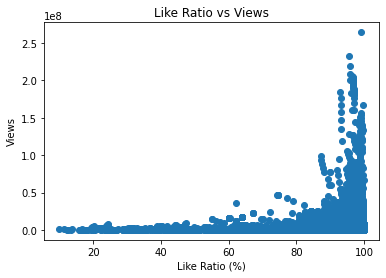

```python
plt.scatter(df['likes_ratio'], df['view_count'])
plt.xlabel(r"Like Ratio (%)")
plt.ylabel("Views")
plt.title("Like Ratio vs Views")
plt.show()
```

This is a bit messy; Let's try another approach. This one using seaborn and using its regression.

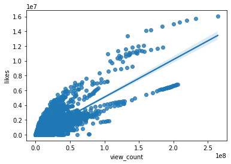

```python
sns.regplot(x='view_count',y='likes',data=df)
plt.show()
```

With this we see a more linear relation between views and likes. This is expected but we can look more into by taking the log(base 10) of each axis

```python
views = df['view_count']
likes = df['likes']

views_log= []
likes_log = []
for i,v in enumerate(zip(views, likes)):
    if v[0] == 0 or v[1] == 0:
        continue
    views_log.append(math.log(v[0],10))
    likes_log.append(math.log(v[1],10))
```

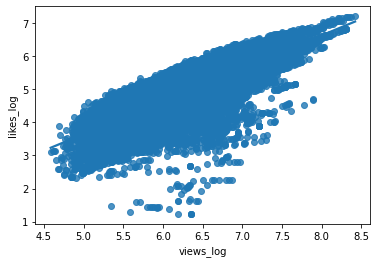

```python
log_df = pd.DataFrame()
log_df['likes_log'] = likes_log
log_df['views_log'] = views_log
sns.regplot(x='views_log',y='likes_log',data=log_df)
plt.show()
```

This is more interesting, but there's too many points. Let's plot the first 1% of the points. This may seem like a tiny amount but keep in mind we have almost 100,000 rows of data, 1% of this is still a thousand rows.

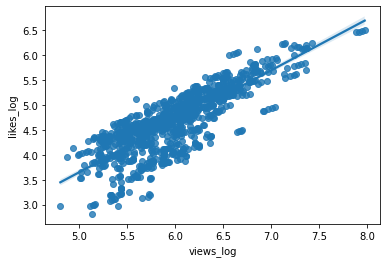

```python
log_df = pd.DataFrame()
log_df['likes_log'] = likes_log[0:len(likes_log)//100]
log_df['views_log'] = views_log[0:len(likes_log)//100]
sns.regplot(x='views_log',y='likes_log',data=log_df)
plt.show()
```

### What percent of trending videos have a high like ratio

Next lets see if most of the videos that made it into trending has a high like ratio

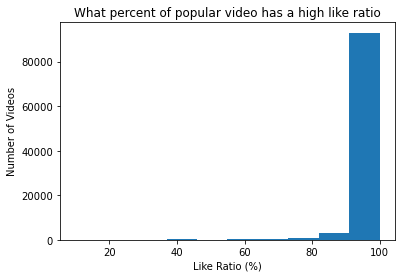

```python
plt.hist(df['likes_ratio'])
plt.xlabel(r"Like Ratio (%)")
plt.ylabel("Number of Videos")
plt.title("What percent of popular video has a high like ratio")
plt.show()
```

We see that the overwhelming majority of the views in trending are in fact very well received! This means that sensational or controversal content (these content would typically have lower like ratios) would have a harder time breaking into trending videos.

## What types of videos are the most popular?

If you wanted to make a video to break into trending, what category of video should you make?

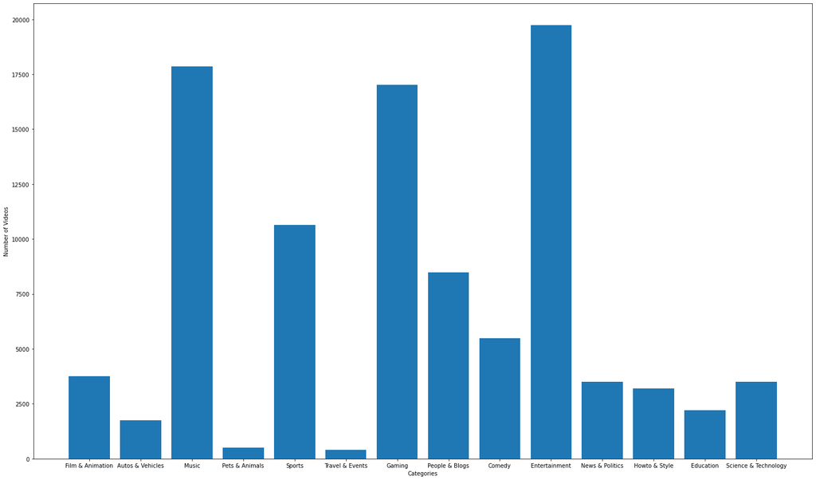

```python
temp = {}
for c in cat_id.values():
    temp[c] = 0

for data in df['category']:
    temp[data] += 1

categories = {}
for c in temp:
    if temp[c] > 100:
        categories[c] = temp[c]
fig = plt.figure(figsize =(25, 15))
plt.bar(categories.keys(), categories.values())
plt.xlabel(r"Categories")
plt.ylabel("Number of Videos")
#plt.title("")
plt.show()
```

## Trending categories per month

We want to see if theres a relationship between the trending date(months) and the chances of a video making it to trending

### Preprocessing

In this part of the project, we'll be looking into the most popular trending categories of YouTube videos per month; however, from looking at the head of our dataframe in the cell above, you can see that the format of the 'trending_date' column is odd and needs some cleaning. Once this column is modified, it can be converted to standard datetime format for further analysis.

```python
# taking a substring of the first ten characters of each trending data
# effectively removing the extra characters at the end
for i, row in df.iterrows():
  df.at[i, "trending_date"] = row["trending_date"][0:10]

# converting trending_date col to datetime format
df['trending_date'] = pd.to_datetime(df['trending_date'], format='%Y.%m.%d')
df.head()
```

|  | title | publishedAt | channelTitle | trending_date | tags | view_count | likes | dislikes | comment_count | comments_disabled | ratings_disabled | category | likes_ratio |
| --- | --- | --- | --- | --- | --- | --- | --- | --- | --- | --- | --- | --- | --- |
| 0 | I ASKED HER TO BE MY GIRLFRIEND... | 2020-08-11T19:20:14Z | Brawadis | 2020-08-12 | brawadis\|prank\|basketball\|skits\|ghost\|funny vi... | 1514614 | 156908 | 5855 | 35313 | False | False | People & Blogs | 96.402745 |
| 1 | Apex Legends \| Stories from the Outlands – “Th... | 2020-08-11T17:00:10Z | Apex Legends | 2020-08-12 | Apex Legends\|Apex Legends characters\|new Apex ... | 2381688 | 146739 | 2794 | 16549 | False | False | Gaming | 98.131516 |
| 2 | I left youtube for a month and THIS is what ha... | 2020-08-11T16:34:06Z | jacksepticeye | 2020-08-12 | jacksepticeye\|funny\|funny meme\|memes\|jacksepti... | 2038853 | 353787 | 2628 | 40221 | False | False | Entertainment | 99.262657 |
| 3 | XXL 2020 Freshman Class Revealed - Official An... | 2020-08-11T16:38:55Z | XXL | 2020-08-12 | xxl freshman\|xxl freshmen\|2020 xxl freshman\|20... | 496771 | 23251 | 1856 | 7647 | False | False | Music | 92.607639 |
| 4 | Ultimate DIY Home Movie Theater for The LaBran... | 2020-08-11T15:10:05Z | Mr. Kate | 2020-08-12 | The LaBrant Family\|DIY\|Interior Design\|Makeove... | 1123889 | 45802 | 964 | 2196 | False | False | Howto & Style | 97.938673 |

Now we want to start analyzing by looking into which video categories are trending in this dataset.

```python
byCat = df.groupby(by=['category']).sum().reset_index()
display(byCat)
```

|  | category | view_count | likes | dislikes | comment_count | comments_disabled | ratings_disabled | likes_ratio |
| --- | --- | --- | --- | --- | --- | --- | --- | --- |
| 0 | Autos & Vehicles | 1914785329 | 88772670 | 1408858 | 7713271 | 0 | 0 | 1.707036e+05 |
| 1 | Comedy | 10511614324 | 718422436 | 11174623 | 39961401 | 5 | 0 | 5.400268e+05 |
| 2 | Education | 3337783703 | 209396163 | 4040488 | 15941268 | 21 | 0 | 2.124092e+05 |
| 3 | Entertainment | 65440917179 | 3346084989 | 62549431 | 223442458 | 356 | 0 | 1.913180e+06 |
| 4 | Film & Animation | 8162675980 | 374676085 | 6686643 | 30691115 | 16 | 0 | 3.655510e+05 |
| 5 | Gaming | 38245601154 | 2112545311 | 38395646 | 169568027 | 98 | 0 | 1.657954e+06 |
| 6 | Howto & Style | 4627675942 | 222634390 | 7266989 | 18647080 | 47 | 0 | 3.095635e+05 |
| 7 | Music | 83492867653 | 5706361753 | 106002834 | 661578759 | 28 | 0 | 1.750666e+06 |
| 8 | News & Politics | 6084677056 | 80036755 | 9979392 | 22407985 | 314 | 0 | 3.068019e+05 |
| 9 | Nonprofits & Activism | 131399890 | 11096562 | 112968 | 397858 | 0 | 0 | 8.624558e+03 |
| 10 | People & Blogs | 18465758586 | 1108635493 | 31225806 | 74720498 | 217 | 0 | 8.246492e+05 |
| 11 | Pets & Animals | 631401256 | 30929729 | 395656 | 2200316 | 0 | 0 | 4.994657e+04 |
| 12 | Science & Technology | 9356091709 | 406897672 | 9343119 | 25099157 | 265 | 0 | 3.378653e+05 |
| 13 | Sports | 21981874704 | 551473512 | 15843036 | 46554551 | 44 | 0 | 1.016712e+06 |
| 14 | Travel & Events | 408323428 | 21577650 | 453556 | 1289756 | 0 | 0 | 4.004674e+04 |

```python
# getting each category's data as a separate df
grouped = df.groupby(df.category)
auto = grouped.get_group("Autos & Vehicles")
com = grouped.get_group("Comedy")
edu = grouped.get_group("Education")
entertain = grouped.get_group("Entertainment")
film = grouped.get_group("Film & Animation")
gaming = grouped.get_group("Gaming")
howto = grouped.get_group("Howto & Style")
music = grouped.get_group("Music")
news = grouped.get_group("News & Politics")
activism = grouped.get_group("Nonprofits & Activism")
blogs = grouped.get_group("People & Blogs")
animals = grouped.get_group("Pets & Animals")
scitech = grouped.get_group("Science & Technology")
sports = grouped.get_group("Sports")
travel = grouped.get_group("Travel & Events")
auto.head()
```

|  | title | publishedAt | channelTitle | trending_date | tags | view_count | likes | dislikes | comment_count | comments_disabled | ratings_disabled | category | likes_ratio |
| --- | --- | --- | --- | --- | --- | --- | --- | --- | --- | --- | --- | --- | --- |
| 105 | $3000 vs. $500 Suspension Upgrade | 2020-08-09T16:00:12Z | Donut Media | 2020-08-12 | donut media\|hi low\|james pumphrey\|nolan skyes\|... | 1354257 | 62586 | 560 | 3888 | False | False | Autos & Vehicles | 99.113166 |
| 127 | Road Rage – Why Motorcycle Riders Smash Windows | 2020-08-09T15:00:01Z | FortNine | 2020-08-12 | motorcycle road rage compilation\|motorcycle cr... | 342870 | 30254 | 580 | 3124 | False | False | Autos & Vehicles | 98.118960 |
| 162 | First Shreds! Testing Our Duramax Swapped Cama... | 2020-08-07T15:00:32Z | Hoonigan Project Cars | 2020-08-12 | Knuckle Busters\|Knuckle Busters 2\|Edelbrock\|Ed... | 466200 | 15363 | 316 | 1272 | False | False | Autos & Vehicles | 97.984565 |
| 187 | Ford Sticks It To Jeep By Taking The New Bronc... | 2020-08-06T21:04:51Z | TFLoffroad | 2020-08-12 | TFLoffroad\|TFL\|2021 ford bronco\|2021\|ford bron... | 511098 | 6700 | 761 | 2191 | False | False | Autos & Vehicles | 89.800295 |
| 215 | We Buy a Donk Project. Goal: 1000HP! Part 1 of 69 | 2020-08-12T16:00:08Z | Hoonigan | 2020-08-13 | Donk\|Box\|Bubble\|Donk magazine\|RIDES Magazine\|C... | 112081 | 6115 | 101 | 2021 | False | False | Autos & Vehicles | 98.375161 |

In order to properly identify the most popular categories per month, we can use the split-up groups of rows (one for each category) and compute the total monthly view count. The total views per month of the 'Autos & Vehicals' category is shown as an example. (Likes are added along with view count solely so that the resultant objects will be dataframes, which is what we want, and not series.)

```python
categories = [auto, com, edu, entertain, film, gaming, howto, music, news, activism, blogs, animals, scitech, sports, travel]
names = ['auto', 'com', 'edu', 'entertain', 'film', 'gaming', 'howto', 'music', 'news', 'activism', 'blogs', 'animals', 'scitech', 'sports', 'travel']
sums = {}
for i in range(len(categories)):
    sums[names[i]] = categories[i].groupby(categories[i].trending_date.dt.month)['view_count','likes'].sum()
sums['auto']
```

| trending_date | view_count | likes |
| --- | --- | --- |
| 1 | 113389596 | 4060354 |
| 2 | 187585344 | 3962879 |
| 3 | 71786108 | 2725930 |
| 4 | 97722045 | 2306466 |
| 5 | 82213650 | 5587252 |
| 6 | 297415169 | 19399228 |
| 7 | 83316454 | 4023365 |
| 8 | 178427336 | 7179923 |
| 9 | 203266951 | 15289605 |
| 10 | 203936100 | 7045607 |
| 11 | 191377634 | 8666578 |
| 12 | 204348942 | 8525483 |

In this step, we make a dictionary mapping each month to the the total view count per appropriate category, for every category. Each key is a number corresponding to a month and each key is a set of tuple: (view_count, category). If the appropriate key already exits in the map, then the tuple/value is appended to that key; otherwise, the key-value pair is initialized in the dictionary.

```python
months = {}
for key in sums:
    # key is the name of the category

    for index, row in sums[key].iterrows():
        if index in months:
            months[index].append((row['view_count'], key))
        else:
            months[index] = [(row['view_count'], key)]

# sorting months accordingly (1-12)
months = {key: val for key, val in sorted(months.items(), key = lambda ele: ele[0])}
#months
```

Now that we have a dictionary mapping each month to its views by category, we can perform a descending sort on these to find the category with most views from each month, which has been the objective of this portion.

```python
# top categories (by views) from each month of the year
for i in range(1,13):
  months[i].sort(reverse=True)
  print('month', i,':',months[i][0][1])
```

[output not shown]

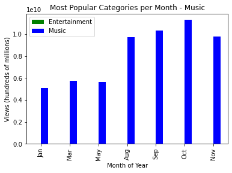

```python
data = [ [1, months[1][0][0]], [3, months[3][0][0]], [5, months[5][0][0]],
         [8, months[8][0][0]], [9, months[9][0][0]],
         [10, months[10][0][0]], [11, months[11][0][0]]]
cols = ['Jan', 'Mar','May','Aug','Sep','Oct','Nov']

df2 = pd.DataFrame(data, cols)

ax = df2.plot(kind='bar', title='Most Popular Categories per Month - Music', color=['g', 'b', 'r', 'c'])
plt.legend(['Entertainment','Music'])
ax.set_xlabel("Month of Year")
ax.set_ylabel("Views (hundreds of millions)")
plt.show()
```

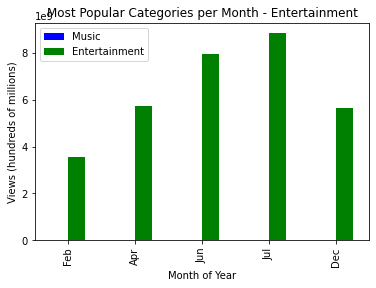

```python
data = [[2, months[2][0][0]], [4, months[3][0][0]],
        [6, months[6][0][0]], [7, months[7][0][0]], [12, months[12][0][0]]]
cols = ['Feb', 'Apr','Jun','Jul','Dec']

df3 = pd.DataFrame(data, cols)

ax = df3.plot(kind='bar', title='Most Popular Categories per Month - Entertainment', color=['b', 'g', 'r', 'c'])
plt.legend(['Music','Entertainment'])
ax.set_xlabel("Month of Year")
ax.set_ylabel("Views (hundreds of millions)")
plt.show()
```

## Controversial Trending Videos

Now, we are going to be looling at controversial videos. We are going to define controversial videos as having:

- like ratio below 50%
- comment count in the upper 40th percentile

The reason for choosing this criteria is it allows us to limit the data set to find trending videos that caused controversey, and at the same time not limiting it too much so that we have enough data to work with.

```python
#controversial videos: high comments, low like ratio


df2 = pd.DataFrame()

 # for each row, if the like ratio is below 50, and comments in upper 40th percentile
for index, row in df.iterrows():
  if row['likes_ratio'] < 50 and stats.percentileofscore(df['comment_count'], row['comment_count']) >= 60:
    df2 = df2.append(row)

#remove duplicate titles (same video trending at a different time)
df2 = df2.drop_duplicates(subset=['title'])
```

We have limited our data set to only contain controversial trending videos based on our criteria. However, we can see that we are not left with that many results. What this mainly tells us is that videos of controverisal nature do not commonly go on the YouTube trending page.

Let's examine this data further. What are the main categories of trending videos that are controvesial?

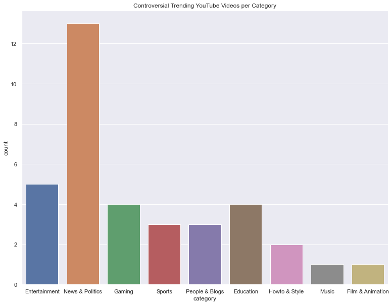

```python
### Bar plot of the number of controversial videos per category
sns.set(rc={'figure.figsize':(13,10)})
plot = sns.countplot(x="category", data=df2)
plot.set(title='Controversial Trending YouTube Videos per Category')

plt.show()
```

From the plot above, we can clearly see that the main category of controversial videos that go on the trending page is "News & Politics".

This tells us that videos regarding politics or world news are more likely to generate a lot of discussion in the comment section, in addition to having a rather low percentage of people liking the video.

This should not be surprising. However, we can also look at the category "News & Politics" in general to see how many of those videos in our dataset are controversial (based on our criteria).

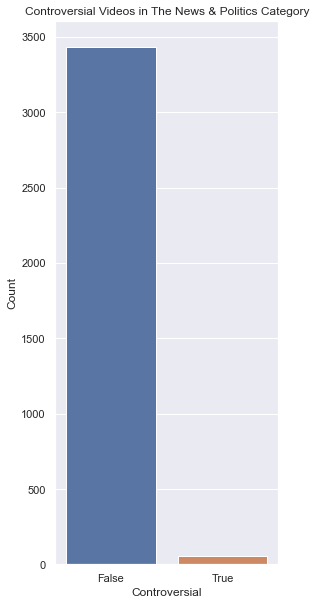

```python
### split "News & Politics" into 'controversial' and 'non_controversial'

df['is_controversial'] = np.nan
df['is_controversial']=df['is_controversial'].astype('boolean')

for index, row in df.iterrows():
  if row['category'] == "News & Politics":
    if row['likes_ratio'] < 50 and stats.percentileofscore(df['comment_count'], row['comment_count']) >= 60:
      df.at[index, 'is_controversial'] = True

    else:
      df.at[index, 'is_controversial'] = False

#plot the two

df = df.dropna(subset=['is_controversial'])
sns.set(rc={'figure.figsize':(4,10)})
ax = sns.countplot(x="is_controversial", data=df)
ax.set(title = 'Controversial Videos in The News & Politics Category',xlabel='Controversial', ylabel='Count')

plt.show()
```

From the bar plot above, we can see that very few trending videos with the category "News & Politics" are controversial. This tells us that despite most of the controversial videos being related to News & Politics, this is a very low percentage when compared to the entire category.

## Conclusion

So from our tutorial we see that to make a trending video we want to first keep the audience engaged. This can take the form of a high ratio of likes and a high ratio of likes to view. Videos in specific categories tend to trend more often (e.g., Music, Entertainment) so it’s more worthwhile to focus on content in those fields. It’s important to note that trending videos are rarely controversial as seen by the very low number of controversial videos in the “News & Politics” category; Note that this category was the one with the highest number of controversial videos so it’s safe extrapolate to all categories.

Hope this helps you make a banger YouTube video channel and I wish to see you on the trend page.